# Risk Factor Analysis

## Outcome Variable

**Outcome Variable:** pers_wast

## Predictor Variables

**Intervention Variable:** nchldlt5

**Adjustment Set:**

- arm
- W_mage
- meducyrs
- feducyrs
- hhwealth_quart
- hfoodsec
- W_mhtcm
- W_mwtkg
- W_mbmi
- W_nrooms
- W_parity
- impfloor
- impsan
- safeh20
- delta_W_mage
- delta_meducyrs
- delta_feducyrs
- delta_hhwealth_quart
- delta_hfoodsec
- delta_W_mhtcm
- delta_W_mwtkg
- delta_W_mbmi
- delta_W_nrooms
- delta_W_parity
- delta_impfloor
- delta_impsan
- delta_safeh20

## Stratifying Variables

The analysis was stratified on these variable(s):

- agecat
- studyid
- country

## Data Summary

| agecat | studyid | country | nchldlt5 | pers_wast | n_cell | n |
| --- | --- | --- | --- | --- | --- | --- |
| 0-24 months | iLiNS-Zinc | BURKINA FASO | 1 | 0 | 488 | 1639 |
| 0-24 months | iLiNS-Zinc | BURKINA FASO | 1 | 1 | 62 | 1639 |
| 0-24 months | iLiNS-Zinc | BURKINA FASO | 2+ | 0 | 958 | 1639 |
| 0-24 months | iLiNS-Zinc | BURKINA FASO | 2+ | 1 | 131 | 1639 |
| 0-24 months | IRC | INDIA | 1 | 0 | 79 | 410 |
| 0-24 months | IRC | INDIA | 1 | 1 | 10 | 410 |
| 0-24 months | IRC | INDIA | 2+ | 0 | 283 | 410 |
| 0-24 months | IRC | INDIA | 2+ | 1 | 38 | 410 |
| 0-24 months | JiVitA-3 | BANGLADESH | 1 | 0 | 9569 | 15793 |
| 0-24 months | JiVitA-3 | BANGLADESH | 1 | 1 | 596 | 15793 |
| 0-24 months | JiVitA-3 | BANGLADESH | 2+ | 0 | 5327 | 15793 |
| 0-24 months | JiVitA-3 | BANGLADESH | 2+ | 1 | 301 | 15793 |
| 0-24 months | LCNI-5 | MALAWI | 1 | 0 | 337 | 711 |
| 0-24 months | LCNI-5 | MALAWI | 1 | 1 | 4 | 711 |
| 0-24 months | LCNI-5 | MALAWI | 2+ | 0 | 368 | 711 |
| 0-24 months | LCNI-5 | MALAWI | 2+ | 1 | 2 | 711 |
| 0-24 months | NIH-Crypto | BANGLADESH | 1 | 0 | 504 | 730 |
| 0-24 months | NIH-Crypto | BANGLADESH | 1 | 1 | 16 | 730 |
| 0-24 months | NIH-Crypto | BANGLADESH | 2+ | 0 | 200 | 730 |
| 0-24 months | NIH-Crypto | BANGLADESH | 2+ | 1 | 10 | 730 |
| 0-24 months | PROVIDE | BANGLADESH | 1 | 0 | 460 | 641 |
| 0-24 months | PROVIDE | BANGLADESH | 1 | 1 | 10 | 641 |
| 0-24 months | PROVIDE | BANGLADESH | 2+ | 0 | 166 | 641 |
| 0-24 months | PROVIDE | BANGLADESH | 2+ | 1 | 5 | 641 |
| 0-24 months | TanzaniaChild2 | TANZANIA, UNITED REPUBLIC OF | 1 | 0 | 1440 | 2157 |
| 0-24 months | TanzaniaChild2 | TANZANIA, UNITED REPUBLIC OF | 1 | 1 | 38 | 2157 |
| 0-24 months | TanzaniaChild2 | TANZANIA, UNITED REPUBLIC OF | 2+ | 0 | 659 | 2157 |
| 0-24 months | TanzaniaChild2 | TANZANIA, UNITED REPUBLIC OF | 2+ | 1 | 20 | 2157 |

The following strata were considered:

- agecat: 0-24 months, studyid: iLiNS-Zinc, country: BURKINA FASO
- agecat: 0-24 months, studyid: IRC, country: INDIA
- agecat: 0-24 months, studyid: JiVitA-3, country: BANGLADESH
- agecat: 0-24 months, studyid: LCNI-5, country: MALAWI
- agecat: 0-24 months, studyid: NIH-Crypto, country: BANGLADESH
- agecat: 0-24 months, studyid: PROVIDE, country: BANGLADESH
- agecat: 0-24 months, studyid: TanzaniaChild2, country: TANZANIA, UNITED REPUBLIC OF

### Dropped Strata

Some strata were dropped due to rare outcomes:

- agecat: 0-24 months, studyid: LCNI-5, country: MALAWI

## Methods Detail

We're interested in the causal parameters $E[Y_a]$ for all values of $a \in \mathcal{A}$. These parameters represent the mean outcome if, possibly contrary to fact, we intervened to set all units to have $A=a$. Under the randomization and positivity assumptions, these are identified by the statistical parameters $\psi_a=E_W[E_{Y|A,W}(Y|A=a,W)]$. In addition, we're interested in the mean of $Y$, $E[Y]$ under no intervention (the observed mean). We will estimate these parameters by using SuperLearner to fit the relevant likelihood factors -- $E_{Y|A,W}(Y|A=a,W)$ and $p(A=a|W)$, and then updating our likelihood fit using a joint TMLE.

For unadjusted analyses ($W=\{\}$), initial likelihoods were estimated using Lrnr_glm to estimate the simple $E(Y|A)$ and Lrnr_mean to estimate $p(A)$. For adjusted analyses, a small library containing Lrnr_glmnet, Lrnr_xgboost, and Lrnr_mean was used.

Having estimated these parameters, we will then use the delta method to estimate relative risks and attributable risks relative to a prespecified baseline level of $A$.

# Results Detail

## Results Plots

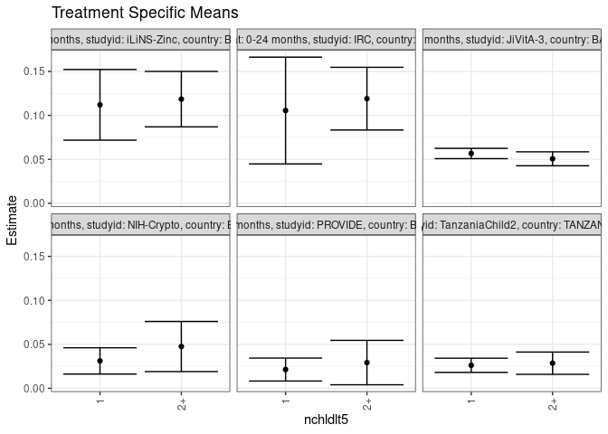

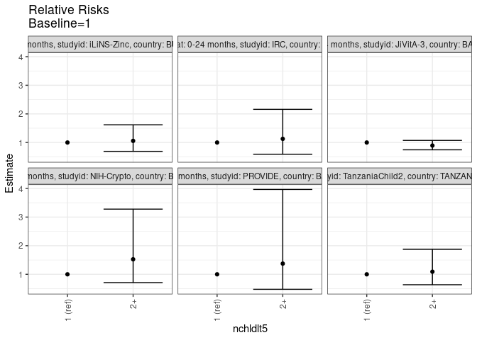

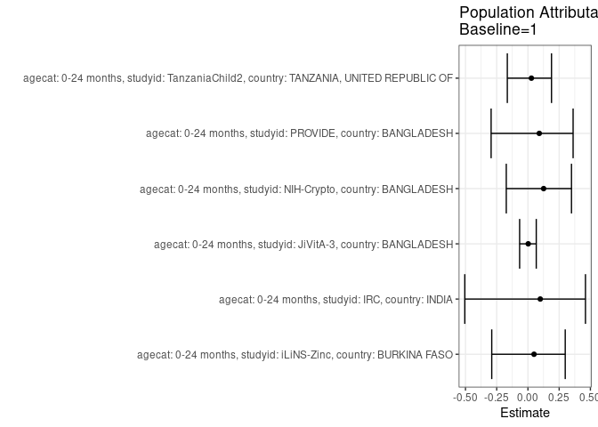

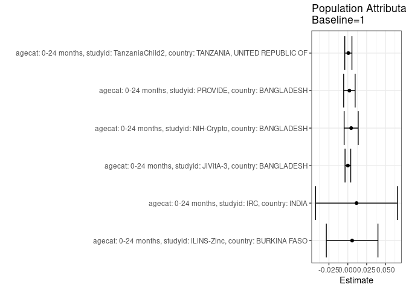

## Results Table

### Parameter: TSM

| agecat | studyid | country | intervention_level | baseline_level | estimate | ci_lower | ci_upper |
| --- | --- | --- | --- | --- | --- | --- | --- |
| 0-24 months | iLiNS-Zinc | BURKINA FASO | 1 | NA | 0.1120091 | 0.0718315 | 0.1521867 |
| 0-24 months | iLiNS-Zinc | BURKINA FASO | 2+ | NA | 0.1184738 | 0.0869422 | 0.1500053 |
| 0-24 months | IRC | INDIA | 1 | NA | 0.1055092 | 0.0447665 | 0.1662519 |
| 0-24 months | IRC | INDIA | 2+ | NA | 0.1190191 | 0.0833462 | 0.1546920 |
| 0-24 months | JiVitA-3 | BANGLADESH | 1 | NA | 0.0566684 | 0.0508292 | 0.0625075 |
| 0-24 months | JiVitA-3 | BANGLADESH | 2+ | NA | 0.0506354 | 0.0427066 | 0.0585641 |
| 0-24 months | NIH-Crypto | BANGLADESH | 1 | NA | 0.0311395 | 0.0162262 | 0.0460528 |
| 0-24 months | NIH-Crypto | BANGLADESH | 2+ | NA | 0.0475027 | 0.0190079 | 0.0759975 |
| 0-24 months | PROVIDE | BANGLADESH | 1 | NA | 0.0212766 | 0.0082203 | 0.0343329 |
| 0-24 months | PROVIDE | BANGLADESH | 2+ | NA | 0.0292398 | 0.0039682 | 0.0545113 |
| 0-24 months | TanzaniaChild2 | TANZANIA, UNITED REPUBLIC OF | 1 | NA | 0.0261441 | 0.0180717 | 0.0342166 |
| 0-24 months | TanzaniaChild2 | TANZANIA, UNITED REPUBLIC OF | 2+ | NA | 0.0285380 | 0.0158503 | 0.0412257 |

### Parameter: E(Y)

| agecat | studyid | country | intervention_level | baseline_level | estimate | ci_lower | ci_upper |
| --- | --- | --- | --- | --- | --- | --- | --- |
| 0-24 months | iLiNS-Zinc | BURKINA FASO | NA | NA | 0.1177547 | 0.0931926 | 0.1423168 |
| 0-24 months | IRC | INDIA | NA | NA | 0.1170732 | 0.0859146 | 0.1482317 |
| 0-24 months | JiVitA-3 | BANGLADESH | NA | NA | 0.0567973 | 0.0526805 | 0.0609141 |
| 0-24 months | NIH-Crypto | BANGLADESH | NA | NA | 0.0356164 | 0.0221630 | 0.0490699 |
| 0-24 months | PROVIDE | BANGLADESH | NA | NA | 0.0234009 | 0.0116889 | 0.0351130 |
| 0-24 months | TanzaniaChild2 | TANZANIA, UNITED REPUBLIC OF | NA | NA | 0.0268892 | 0.0200612 | 0.0337172 |

### Parameter: RR

| agecat | studyid | country | intervention_level | baseline_level | estimate | ci_lower | ci_upper |
| --- | --- | --- | --- | --- | --- | --- | --- |
| 0-24 months | iLiNS-Zinc | BURKINA FASO | 1 | 1 | 1.0000000 | 1.0000000 | 1.000000 |
| 0-24 months | iLiNS-Zinc | BURKINA FASO | 2+ | 1 | 1.0577156 | 0.6911240 | 1.618758 |
| 0-24 months | IRC | INDIA | 1 | 1 | 1.0000000 | 1.0000000 | 1.000000 |
| 0-24 months | IRC | INDIA | 2+ | 1 | 1.1280444 | 0.5894338 | 2.158825 |
| 0-24 months | JiVitA-3 | BANGLADESH | 1 | 1 | 1.0000000 | 1.0000000 | 1.000000 |
| 0-24 months | JiVitA-3 | BANGLADESH | 2+ | 1 | 0.8935382 | 0.7441044 | 1.072982 |
| 0-24 months | NIH-Crypto | BANGLADESH | 1 | 1 | 1.0000000 | 1.0000000 | 1.000000 |
| 0-24 months | NIH-Crypto | BANGLADESH | 2+ | 1 | 1.5254808 | 0.7098839 | 3.278130 |
| 0-24 months | PROVIDE | BANGLADESH | 1 | 1 | 1.0000000 | 1.0000000 | 1.000000 |
| 0-24 months | PROVIDE | BANGLADESH | 2+ | 1 | 1.3742690 | 0.4761342 | 3.966561 |
| 0-24 months | TanzaniaChild2 | TANZANIA, UNITED REPUBLIC OF | 1 | 1 | 1.0000000 | 1.0000000 | 1.000000 |
| 0-24 months | TanzaniaChild2 | TANZANIA, UNITED REPUBLIC OF | 2+ | 1 | 1.0915624 | 0.6356956 | 1.874338 |

### Parameter: PAR

| agecat | studyid | country | intervention_level | baseline_level | estimate | ci_lower | ci_upper |
| --- | --- | --- | --- | --- | --- | --- | --- |
| 0-24 months | iLiNS-Zinc | BURKINA FASO | 1 | NA | 0.0057456 | -0.0284515 | 0.0399427 |
| 0-24 months | IRC | INDIA | 1 | NA | 0.0115639 | -0.0426923 | 0.0658202 |
| 0-24 months | JiVitA-3 | BANGLADESH | 1 | NA | 0.0001289 | -0.0036482 | 0.0039061 |
| 0-24 months | NIH-Crypto | BANGLADESH | 1 | NA | 0.0044770 | -0.0048415 | 0.0137954 |
| 0-24 months | PROVIDE | BANGLADESH | 1 | NA | 0.0021243 | -0.0054689 | 0.0097175 |
| 0-24 months | TanzaniaChild2 | TANZANIA, UNITED REPUBLIC OF | 1 | NA | 0.0007450 | -0.0039926 | 0.0054827 |

### Parameter: PAF

| agecat | studyid | country | intervention_level | baseline_level | estimate | ci_lower | ci_upper |
| --- | --- | --- | --- | --- | --- | --- | --- |
| 0-24 months | iLiNS-Zinc | BURKINA FASO | 1 | NA | 0.0487930 | -0.2897649 | 0.2984809 |
| 0-24 months | IRC | INDIA | 1 | NA | 0.0987753 | -0.5054881 | 0.4605032 |
| 0-24 months | JiVitA-3 | BANGLADESH | 1 | NA | 0.0022700 | -0.0665149 | 0.0666186 |
| 0-24 months | NIH-Crypto | BANGLADESH | 1 | NA | 0.1256991 | -0.1734701 | 0.3485970 |
| 0-24 months | PROVIDE | BANGLADESH | 1 | NA | 0.0907801 | -0.2947917 | 0.3615338 |
| 0-24 months | TanzaniaChild2 | TANZANIA, UNITED REPUBLIC OF | 1 | NA | 0.0277081 | -0.1651148 | 0.1886194 |